# Assignment 5 - Helmetsberger Maria & Gstoettenmayr Jonas

```python
import os
import matplotlib.pyplot as plt
import tensorflow as tf
import keras
import keras.layers as layers
import numpy as np
```

```python
OPTIONS = ["cat", "dog", "fox"]
data_path = '/home/azureuser/cloudfiles/code/Users/s2410929009/NDL3Repo/assignments/assignment_5/data/'
```

## 1) Preprocessing the data

DISCLAIMER: at this point we didn't yet know about the keras function that reads in all the images and modifies them :C

```python
folder_path = data_path+"raw/"
```

Our original dataset was not very clean so we cleaned it up and gave it uniform formating

```python
for filename in os.listdir(folder_path):
    if filename.endswith(".jpeg"):
        # Create the new name
        new_name = filename.replace(".jpeg", ".jpg")

        # Join path with names and rename
        src = os.path.join(folder_path, filename)
        dst = os.path.join(folder_path, new_name)

        os.rename(src, dst)
        print(f'Renamed: {filename} -> {new_name}')
```

We resize our images with padding to all be the same size

We choose padding here for a mulitude of reasons:

- the images are all of different sizes (pixel amounts)
- the images do not always have the animal in the middle
- the images are all of different aspect ratios

As such it would require a quite complicated system to cut the images into the correct shape.

We did not want to squish them as such padding remained the best choise for both machine and time efficiency.

```python
def resize_with_pad(image_path, target_size=(128, 128)):
    img = tf.io.read_file(image_path)
    img = tf.image.decode_jpeg(img, channels=3)
    img = tf.image.resize_with_pad(img, target_size[0], target_size[1])
    img = img / 255.0  # Normalize
    return img
```

```python
images = {option:[] for option in OPTIONS}
```

```python
for option in OPTIONS:
    for filename in os.listdir(folder_path+option):
        if not filename.endswith(".jpg"): continue
        images[option].append(resize_with_pad(folder_path+option+"/"+filename))
```

```python
save_to = data_path + "processed/"
save_to
```

```
'/home/azureuser/cloudfiles/code/Users/s2410929009/NDL3Repo/assignments/assignment_5/data/processed/'
```

```python
for k, v in images.items():
    for i, img in enumerate(v):
        keras.utils.save_img(save_to+f"{k}/{k}_{i}.jpg", img)
```

## 2) Augmentation

In this layer we define how we augment our images, to make sure it learns not just the images but the concept behind cat

```python
from keras.layers import RandomFlip, RandomRotation, RandomZoom, RandomContrast, RandomGrayscale
```

```python
folder_path = data_path+"processed/"
```

```python
images = {option:[] for option in OPTIONS}
```

```python
train, test = keras.utils.image_dataset_from_directory(
    folder_path,
    labels="inferred",
    class_names=OPTIONS,
    color_mode="rgb",
    batch_size=None,
    shuffle=True,
    image_size=(128, 128),
    seed=42,
    validation_split=0.2,
    subset="both",
    verbose=True,
)
```

```
Found 309 files belonging to 3 classes.
Using 248 files for training.
Using 61 files for validation.
```

We choose the following augmentations:

- random flip
- random rotation
- random zoom
- random contract
- random grayscale

They change the way you look at the image as well as the underlying data of the image, allowing for a variety of different compositions for the model to see the aniimals in.

For the hyperparameters we simply choose ones that changes the image, but not to drastically, they were eye measure on the example down below.

```python
data_augmentation = keras.Sequential([
    RandomFlip("horizontal"),
    RandomRotation(0.1),
    RandomZoom(0.15),
    RandomContrast([0,0.3]),
    RandomGrayscale(0.1)
])
```

```python
images_to_test = []
for i, x in enumerate(train.as_numpy_iterator()):
    if i > 6: break
    images_to_test.append(x[0])
```

```python
images_to_test[0].shape
```

```
(128, 128, 3)
```

```python
augmented_images = data_augmentation(images_to_test)
augmented_images = augmented_images.numpy().astype(np.uint8)
```

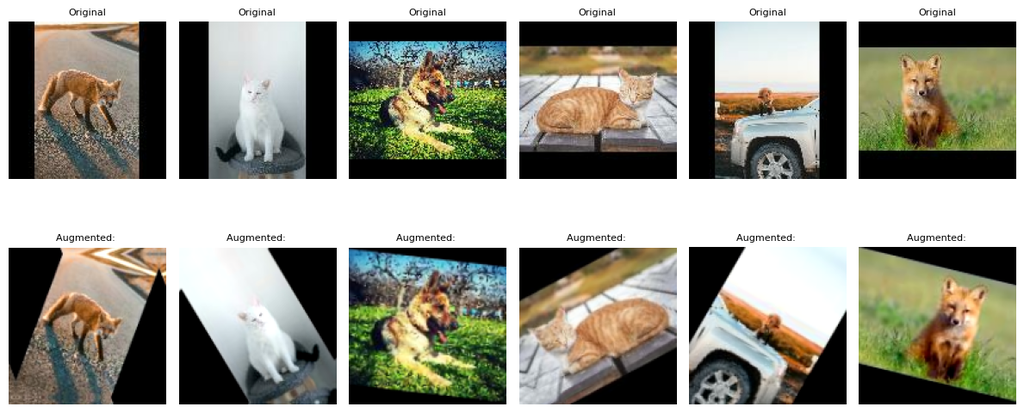

```python
import matplotlib.pyplot as plt
fig, axes = plt.subplots(2, 6, figsize=(12, 6))
for i in range(6):

    axes[0, i].imshow(images_to_test[i]/255)
    axes[0, i].set_title(f"Original", fontsize=8)
    axes[0, i].axis('off')


    axes[1, i].imshow(augmented_images[i].astype(np.uint8))
    axes[1, i].set_title(f"Augmented: ", fontsize=8)
    axes[1, i].axis('off')

plt.tight_layout()
plt.show()
```

## 3) Model

```python
from keras.layers import GlobalAveragePooling2D, Dense, Dropout
from keras import Model
import keras.layers as layers

import numpy as np
import matplotlib.pyplot as plt
from sklearn.metrics import confusion_matrix, classification_report, ConfusionMatrixDisplay
```

LLM usage: prompt "i am working with keras i wish to split of a bit of the train set before training and pass the rest as a validation set"

answer:

```
uselsess code
# Calculate split sizes (e.g., 10% for validation from train)
train_size = train.cardinality().numpy()
val_size = int(0.1 * train_size)
train_size = train_size - val_size

# Split train into train + val
val = train.take(val_size)
train = train.skip(val_size)

# Now batch and prefetch
train_ds = train.batch(8).prefetch(buffer_size=-1)
val_ds = val.batch(8).prefetch(buffer_size=-1)
test_ds = test.batch(8).prefetch(buffer_size=-1)
useless code
```

Since we can't batch it if we want to look at the images above I batch it here and split the training set into train and validation

```python
# Calculate split sizes (e.g., 10% for validation from train)
train_size = train.cardinality().numpy()
val_size = int(0.2 * train_size)
train_size = train_size - val_size

# Split train into train + val
val = train.take(val_size)
train = train.skip(val_size)

train_ds = train.batch(8).prefetch(buffer_size=-1)
val_ds = val.batch(8).prefetch(buffer_size=-1)
test_ds = test.batch(8).prefetch(buffer_size=-1)
```

```python
def eval_classification(model, test_ds, class_names=None, model_name=None):
    """Evaluate classification model and display confusion matrix."""

# Get predictions and true labels
    y_pred_probs = model.predict(test_ds, verbose=0)
    y_pred = np.argmax(y_pred_probs, axis=1)
    y_true = np.concatenate([y for x, y in test_ds], axis=0)

# Evaluate model
    test_loss, test_acc = model.evaluate(test_ds, verbose=0)

# Print results
    print(f"\n{'='*50}")
    print(f"  {model_name or 'Model'} - Classification Results")
    print(f"{'='*50}")
    print(f"  Test Loss:     {test_loss:.4f}")
    print(f"  Test Accuracy: {test_acc:.4f} ({test_acc*100:.2f}%)")
    print(f"{'='*50}\n")

    print(classification_report(y_true, y_pred, target_names=class_names))

# Create confusion matrix
    cm = confusion_matrix(y_true, y_pred)
    fig, ax = plt.subplots(figsize=(10, 8))
    disp = ConfusionMatrixDisplay(confusion_matrix=cm, display_labels=class_names)
    disp.plot(ax=ax, cmap='Blues', values_format='d')
    plt.title(f"{model_name or 'Model'} - Confusion Matrix")
    plt.xticks(rotation=45, ha='right')
    plt.tight_layout()
    plt.show()

    return test_loss, test_acc
```